# Quality Control of Peptide Data with the `pmartR` Package

### Filter Samples

To identify any samples that are potential outliers or anomalies (due to sample quality, preparation, or processing circumstances), we use a robust Mahalanobis distance (rMd) (Matzke et al. 2011) score based on 2-5 metrics. The possible metrics are:

- Correlation
- Proportion of data that is missing (“Proportion_Missing”)
- Median absolute deviation (“MAD”)
- Skewness
- Kurtosis

The rMd score can be mapped to a p-value, and a p-value threshold used to identify potentially outlying samples. In general, for proteomics data we recommend using correlation, proportion missing, MAD, and skew.

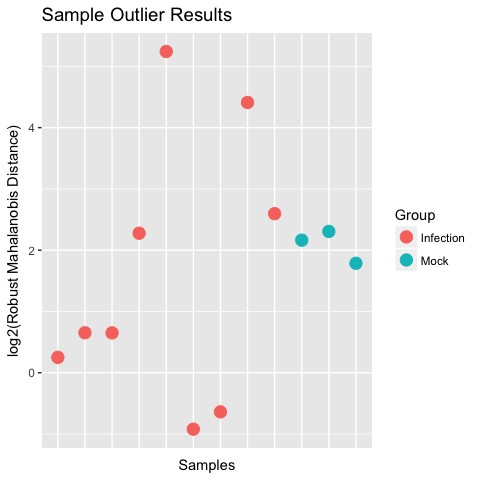

```r
myfilter <- rmd_filter(mypepData, metrics = c("Correlation", "Proportion_Missing", "MAD", "Skewness"))

plot(myfilter)
```

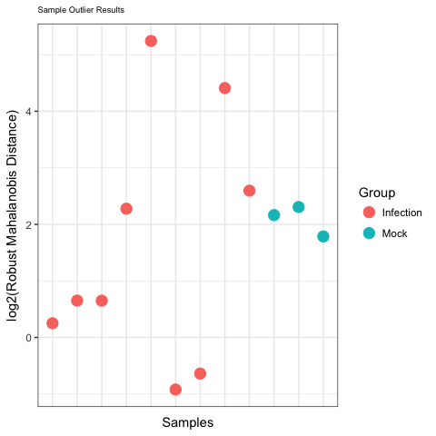

```r
plot(myfilter, title_size=7, bw_theme=TRUE)
```

```r
summary(myfilter, pvalue_threshold = 0.001)
```

```
##
## Summary of RMD Filter
## ----------------------
## P-values:
##
##      Min.   1st Qu.    Median      Mean   3rd Qu.      Max.
## 0.0000001 0.2686711 0.4152817 0.5050117 0.8306939 0.9707249
##
## Metrics Used: MAD, Skewness, Corr, Proportion_Missing
##
## Filtered Samples: Infection5, Infection8
```

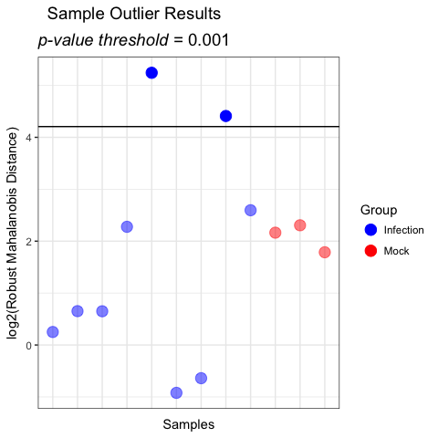

```r
plot(myfilter, pvalue_threshold = 0.001, bw_theme=TRUE)
```

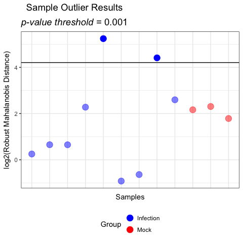

```r
plot(myfilter, pvalue_threshold = 0.001, bw_theme=TRUE, legend_position="bottom")
```

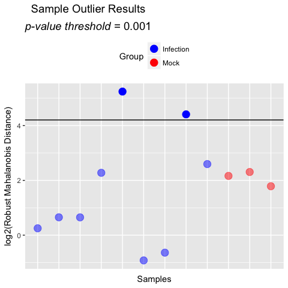

```r
plot(myfilter, pvalue_threshold = 0.001, legend_position="top")
```

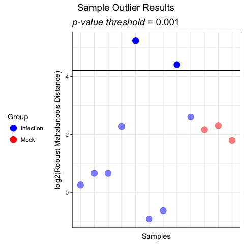

```r
plot(myfilter, pvalue_threshold = 0.001, bw_theme=TRUE, legend_position="left")
```

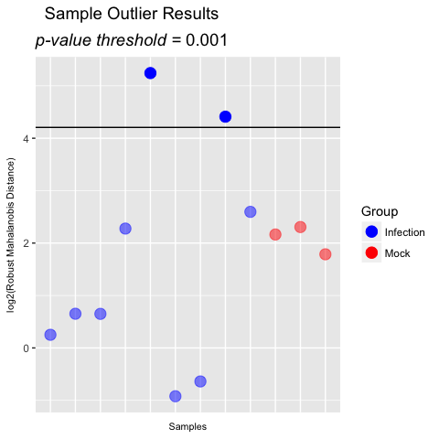

```r
plot(myfilter, pvalue_threshold = 0.001, x_lab_size = 8, y_lab_size = 8)
```

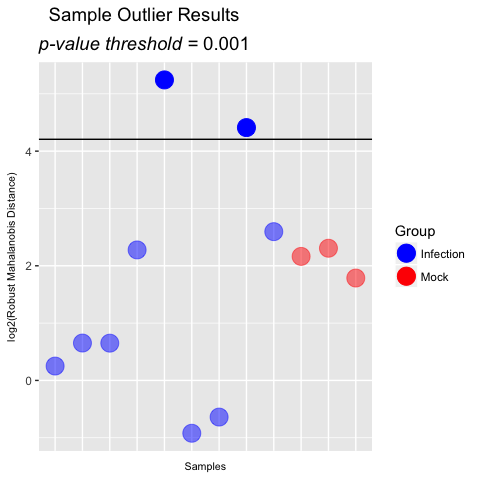

```r
plot(myfilter, pvalue_threshold = 0.001, x_lab_size = 8, y_lab_size = 8, point_size = 6)
```

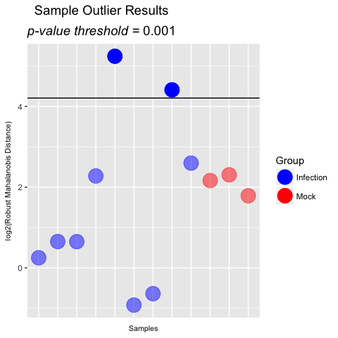

```r
plot(myfilter, pvalue_threshold = 0.001, x_lab_size = 8, y_lab_size = 8, point_size = 7)
```

Using the output from the `summary()` function, we can explore the outliers identified to see what metrics are driving their outlier-ness. Box plots for each metric are plotted, with the specified sample marked with an ‘X’.

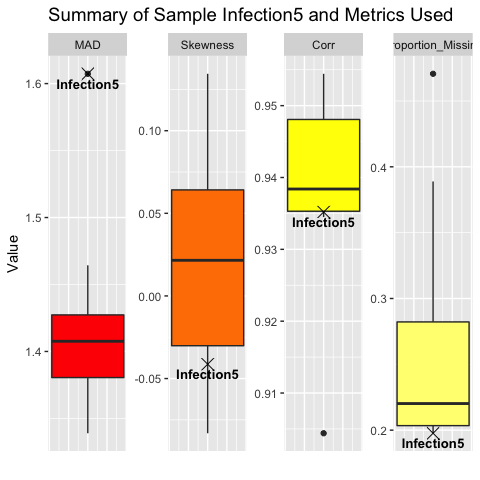

```r
plot(myfilter, sampleID = "Infection5")
```

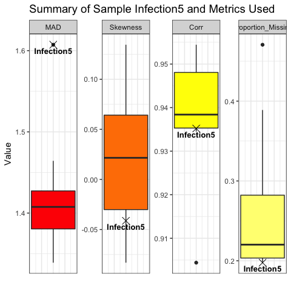

```r
plot(myfilter, sampleID = "Infection5", bw_theme=TRUE)
```

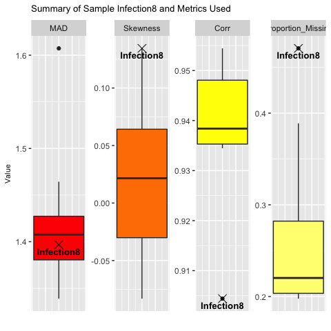

```r
plot(myfilter, sampleID = "Infection8", title_size = 10, y_lab_size=8)
```

We can see that Infection5 has the highest MAD, low skewness, and almost the lowest correlation, but the lowest proportion missing compared to the other samples. Infection 8 has MAD close to the median MAD value, the highest skew, the lowest correlation, and the highest proportion of missing data. We can use this information to determine whether to remove either or both of these samples. Sometimes it is also useful to look at additional data summaries to inform outlier removal, such as a principal components plot or correlation heat map (below).

### Normalize Data

The next step in a typical workflow is to normalize the data.

Normalization approaches consist of a subset method and a normalization function (Åstrand 2003),(Gautier et al. 2004). Available subset methods include:

- Percentage of peptides present (PPP): Subset the data to peptides present in at least $p$ percent of samples. This subset method is specified as “ppp”.
- Rank invariant peptides (RIP): First subset peptides to those present in every sample (e.g. complete peptides). Next, subject each peptide to a Kruskal Wallis test on group, and those peptides *not* significant at a given p-value threshold are retained as invariant. This subset method is specified as “rip”.
- PPP-RIP: Rank invariant peptides among peptides present in a given percentage of samples. This subset method is specified as “ppp_rip”.
- Top “l” order statistics (LOS): The peptides with intensities in the top “l” order statistics are retained. This subset method is specified as “los”.

Available normalization functions include:

- Median centering: The sample-wise median (median of all peptides in a given sample) is subtracted from each peptide in the corresponding sample. This normalization method is specified as “median”.
- Mean centering: The sample-wise mean (mean of all peptides in a given sample) is subtracted from each peptide in the corresponding sample. This normalization method is specified as “mean”.
- Z-score transformation: The sample-wise mean (mean of all peptides in a given sample) is subtracted from each peptide, and the result is divided by the sample-wise standard deviation (standard deviation of all peptides in a given sample) in the corresponding sample. This normalization method is specified as “zscore”.
- Median absolute deviation (MAD) transformation: The sample-wise median (median of all peptides in a given sample) is subtracted from each peptide, and the result is divided by the sample-wise MAD (MAD of all peptides in a given sample) in the corresponding sample. This normalization method is specified as “mad”.

There are two ways to go about normalizing data in the pmartRqc package. If you know the normalization approach you’d like to use, you can directly specify it in the `normalize_data()` function. Or, if you want to see how compatible different normalization approaches are with your dataset, you can use the `spans()` function [UNDER DEVELOPMENT].

We can go straight to the normalization, if we know what approach we want to use.

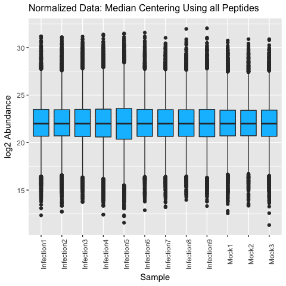

```r
# Normalize using all peptides and median centering #
norm_object <- normalize_global(omicsData = mypepData, subset_fn = "all", norm_fn = "median", apply_norm = FALSE, backtransform = TRUE)
norm_data <- normalize_global(omicsData = mypepData, subset_fn = "all", norm_fn = "median", apply_norm = TRUE, backtransform = TRUE)
plot(norm_data, title_plot="Normalized Data: Median Centering Using all Peptides", title_size=12)
```

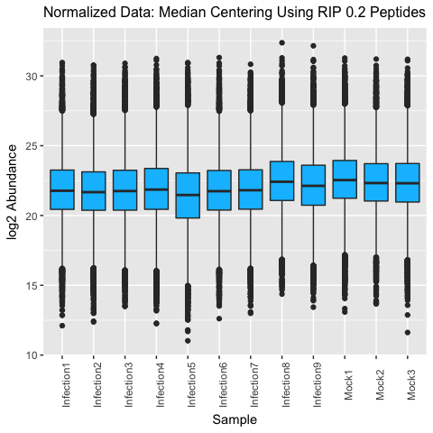

```r
# Normalize using RIP 0.2 and median centering #
norm_object <- normalize_global(omicsData = mypepData, subset_fn = "rip", params=list(rip=0.2), norm_fn = "median", apply_norm = FALSE, backtransform = TRUE)
norm_data <- normalize_global(omicsData = mypepData, subset_fn = "rip", params=list(rip=0.2), norm_fn = "median", apply_norm = TRUE, backtransform = TRUE)
plot(norm_data, title_plot="Normalized Data: Median Centering Using RIP 0.2 Peptides", title_size=12)
```

Below we use SPANS to select a normalization approach and then normalize the data. [UNDER DEVELOPMENT]

```r
# data_norm <- normalize_data(mypepData, subset_fn="ppp.5", norm_fun="median", backtransform=TRUE)
```

### Summarize Data

#### Probabilistic Principal Components Analysis

Probabilistic is a PCA algorithm that can be used in the presence of missing data. We use the `dim_reduction()` function in pmartRqc, specifying the dataset and the number of principal components to return (default value of 2 principal components). The `summary()` and `plot()` functions operate on the results of the `dim_reduction()` function.

Note that `dim_reduction()` requires that the `group_designation()` function has been run.

```r
pca_results <- dim_reduction(norm_data, k = 2)

summary(pca_results)
```

```
## Summary of 'dimRes' Object
```

```
##     R_squaredPC1     0.537PC2     0.338
```

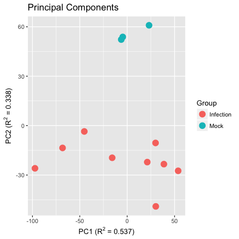

```r
plot(pca_results)
```

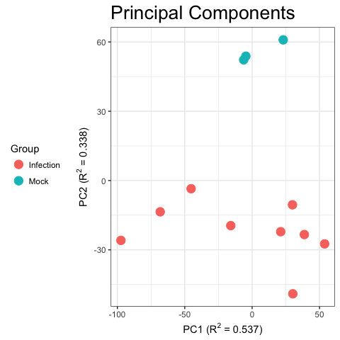

```r
plot(pca_results, title_size = 20, bw_theme=TRUE, legend_position="left")
```

#### Correlation Heatmap

Pearson correlation between samples is calculated based on pairwise complete biomolecules.

```r
correlation_results <- cor_result(norm_data)

summary(correlation_results)
```

```
## Summary of Correlation Matrix (Upper Triangle)
##
##    Min. 1st Qu.  Median    Mean 3rd Qu.    Max.
##  0.7804  0.8688  0.9143  0.9032  0.9496  0.9722
```

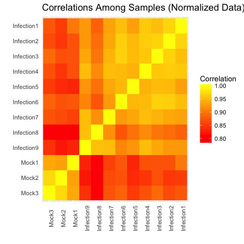

```r
plot(correlation_results)
```

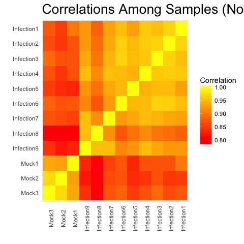

```r
plot(correlation_results, title_size = 20)
```

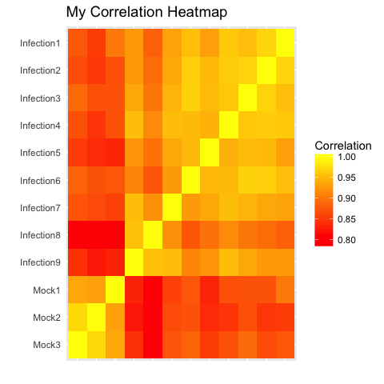

```r
plot(correlation_results, x_lab=FALSE, title_plot="My Correlation Heatmap")
```

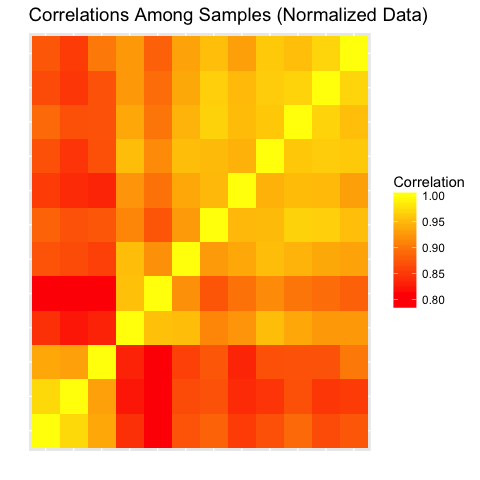

```r
plot(correlation_results, x_lab=FALSE, y_lab=FALSE)
```

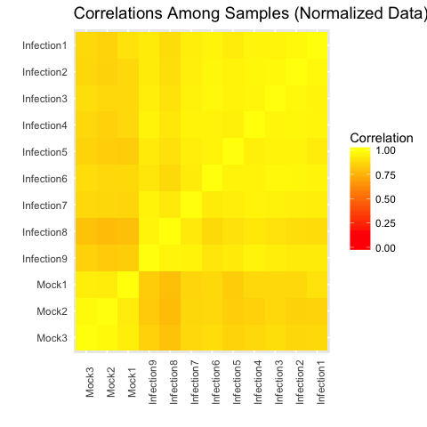

```r
plot(correlation_results, colorbar_lim=c(0,1))
```

#### Missing Data

Patterns of missing data can be explored using the `missingval_result()` and `plot_missingval()` functions.

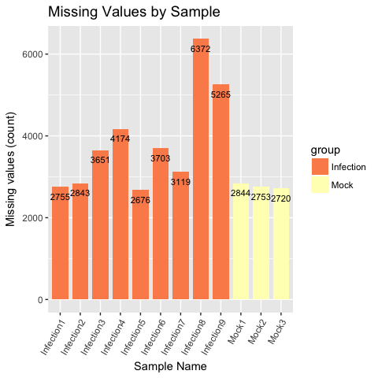

```r
results <- missingval_result(mypepData)


plot(results, type = "bySample")
```

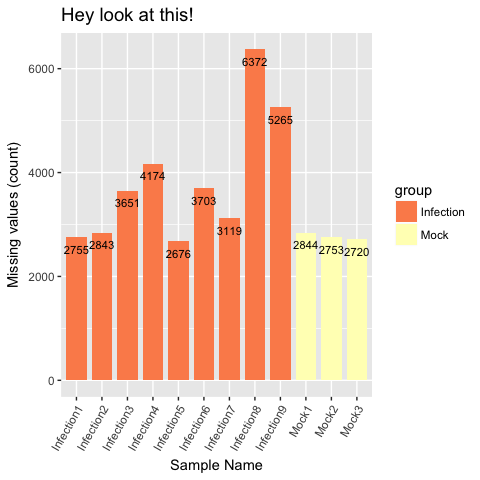

```r
plot(results, type = "bySample", title_plot="Hey look at this!")
```

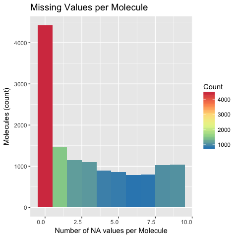

```r
plot(results, type = "byMolecule", x_lab_angle = 0)
```

In addition, the `missingval_scatterplot()` and `missingval_heatmap()` functions provide more views of the missing data.

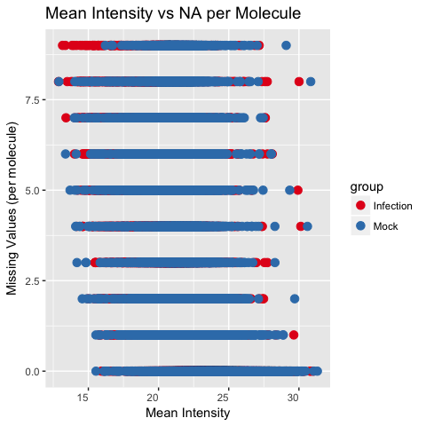

```r
missingval_scatterplot(mypepData, palette = "Set1")
```

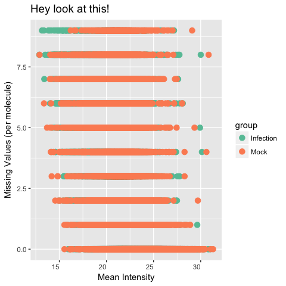

```r
missingval_scatterplot(mypepData, title_plot="Hey look at this!", palette = "Set2")
```

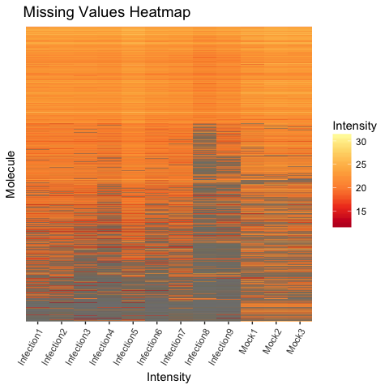

```r
missingval_heatmap(mypepData)
```

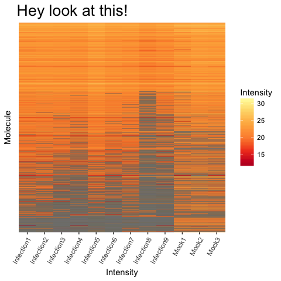

```r
missingval_heatmap(mypepData, title_size = 20, title_plot = "Hey look at this!")
```

### Protein Quantification Methods

Protein quantification can be done using the `protein_quant()` function, either with or without accounting for different isoforms of the proteins, also called ’proteoforms. Regardless of whether the user is accounting for protein isoforms, they must specify a method for rolling peptides up to proteins (one of “rollup”, “rollup”, “qrollup”, or “zrollup”) and a function to use for combining the peptide-level data (either “mean” or “median”). When the user does wish to account for protein isoforms, they have two options for doing so: Bayesian Proteoform Quantification (BP-Quant) (Webb-Robertson et al. 2014) or Protein Quantification via Peptide Quality-Control (PQPQ).

The `protein_quant()` function returns an object of class proData.

#### Rollup Methods

In the rrollup method, all peptides that map to a single protein are scaled based on a chosen reference peptide, which is the peptide with most observations. Next the average or mean of the scaled peptides is set as the relative protein abundance. (Matzke et al. 2013)

The qrollup method starts with all peptides that map to a single protein. Next peptides are chosen according to an abundance cutoff value and the average or mean of the scaled peptides is set as the protein abundance.

In the zrollup method, scaling is done similarly to the z-score formula (except with medians instead of means). The scaling formula is applied to peptides that map to a single protein and then the mean or median of the scaled peptides is set as protein abundance (from DAnTE article). The rollup method is similar to rrollup method, except there is no scaling involved in these methods. Either the mean or median is applied to all peptides that map to a single protein to obtain protein abundance.(Polpitiya et al. 2008)

```r
print(mypepData)
```

```
## only first 5 columns are shown
```

```
## e_data
##       Mass_Tag_ID       Infection1       Infection2       Infection3
## 1            1047 24.0977890271502 24.2586430890449 24.3063144953587
## 2            1055 26.7068342739391 26.7828156404207 26.6612183907909
## 3            1104 30.7065934086211 30.7425913444275 30.6655890043089
## 4            1110 21.2943492668101 22.0257451732308 22.2104070799242
## 5            ----             ----             ----             ----
## 13536   391590766             <NA>             <NA>   24.63451567532
## 13537   391592560             <NA>  19.588993640402             <NA>
## 13538   446044414  25.247950233078 25.3198402289036  24.719789713716
## 13539   477686982 19.6246669643942 17.8053030372927             <NA>
##             Infection4
## 1     24.1179547083477
## 2     26.1511633286756
## 3     31.1831803148936
```

[output cut: 30 more lines]

```r
mypepdata_median<- protein_quant(pepData = mypepData, method = "rollup", combine_fn = "median")
print(mypepdata_median)
```

```
## only first 5 columns are shown
```

```
## e_data
##                           Protein       Infection1       Infection2
## 1                      ALBU_HUMAN 24.4608549951363 24.2586430890449
## 2                      RL40_HUMAN 21.7211926659928 23.9101858693601
## 3                       CYC_HUMAN 21.5081804259878  21.834378774131
## 4                       G3P_HUMAN 23.8412098967255 23.9806642384154
## 5                            ----             ----             ----
## 2250                  GSDMB_HUMAN             <NA>             <NA>
## 2251 gi|29836496|ref|NP_828851.1| 23.3006664739019 23.3765121868188
## 2252                 H1N1_CA04_NP             <NA>  19.588993640402
## 2253                  NXPH2_HUMAN 19.6246669643942 17.8053030372927
##            Infection3       Infection4
## 1    24.3063144953587 24.7939313827039
## 2    23.0238769045738 22.6237736770583
## 3    22.2104070799242 21.5584384643237
```

[output cut: 30 more lines]

```r
rm(mypepdata_median)

mypepdata_rrollup<- protein_quant(pepData = mypepData, method = "rrollup")
print(mypepdata_rrollup)
```

```
## only first 5 columns are shown
```

```
## e_data
##                           Protein       Infection1       Infection2
## 1                      ALBU_HUMAN 30.7065934086211 30.7671906192154
## 2                      RL40_HUMAN 23.7976288758341 23.9101858693601
## 3                       CYC_HUMAN 22.4680035116845 22.5158943631228
## 4                       G3P_HUMAN 28.7947455369585 28.5845049740273
## 5                            ----             ----             ----
## 2250                  GSDMB_HUMAN             <NA>             <NA>
## 2251 gi|29836496|ref|NP_828851.1| 25.7431166625012 25.8189623754182
## 2252                 H1N1_CA04_NP             <NA>  19.588993640402
## 2253                  NXPH2_HUMAN 19.6246669643942 17.8053030372927
##            Infection3       Infection4
## 1    30.6807743112101 31.1718200556252
## 2    23.9257719989507  23.638291219064
## 3    22.7024833446101  21.912984440018
```

[output cut: 30 more lines]

```r
rm(mypepdata_rrollup)
```

### Peptide or Protein Statistics

## References

Ahmed, SE. 1995. “A Pooling Methodology for Coefficient of Variation.” *Sankhyā: The Indian Journal of Statistics, Series B*. JSTOR, 57–75.

Åstrand, Magnus. 2003. “Contrast Normalization of Oligonucleotide Arrays.” *Journal of Computational Biology* 10 (1). Mary Ann Liebert, Inc.: 95–102.

Gautier, Laurent, Leslie Cope, Benjamin M Bolstad, and Rafael A Irizarry. 2004. “Affy—analysis of Affymetrix Genechip Data at the Probe Level.” *Bioinformatics* 20 (3). Oxford University Press: 307–15.

Matzke, Melissa M, Joseph N Brown, Marina A Gritsenko, Thomas O Metz, Joel G Pounds, Karin D Rodland, Anil K Shukla, et al. 2013. “A Comparative Analysis of Computational Approaches to Relative Protein Quantification Using Peptide Peak Intensities in Label-Free Lc-Ms Proteomics Experiments.” *Proteomics* 13 (3-4). Wiley Online Library: 493–503.

Matzke, Melissa M, Katrina M Waters, Thomas O Metz, Jon M Jacobs, Amy C Sims, Ralph S Baric, Joel G Pounds, and Bobbie-Jo M Webb-Robertson. 2011. “Improved Quality Control Processing of Peptide-Centric Lc-Ms Proteomics Data.” *Bioinformatics* 27 (20). Oxford University Press: 2866–72.

Polpitiya, Ashoka D, Wei-Jun Qian, Navdeep Jaitly, Vladislav A Petyuk, Joshua N Adkins, David G Camp, Gordon A Anderson, and Richard D Smith. 2008. “DAnTE: A Statistical Tool for Quantitative Analysis of-Omics Data.” *Bioinformatics* 24 (13). Oxford University Press: 1556–8.

Stacklies, Wolfram, Henning Redestig, Matthias Scholz, Dirk Walther, and Joachim Selbig. 2007. “PcaMethods—a Bioconductor Package Providing Pca Methods for Incomplete Data.” *Bioinformatics* 23 (9). Oxford University Press: 1164–7.

Webb-Robertson, Bobbie-Jo M, Melissa M Matzke, Susmita Datta, Samuel H Payne, Jiyun Kang, Lisa M Bramer, Carrie D Nicora, et al. 2014. “Bayesian Proteoform Modeling Improves Protein Quantification of Global Proteomic Measurements.” *Molecular & Cellular Proteomics* 13 (12). ASBMB: 3639–46.